# Intervalos de Confianza

Edimer David Jaramillo

29 de mayo de 2018

# Inferencia Estadística

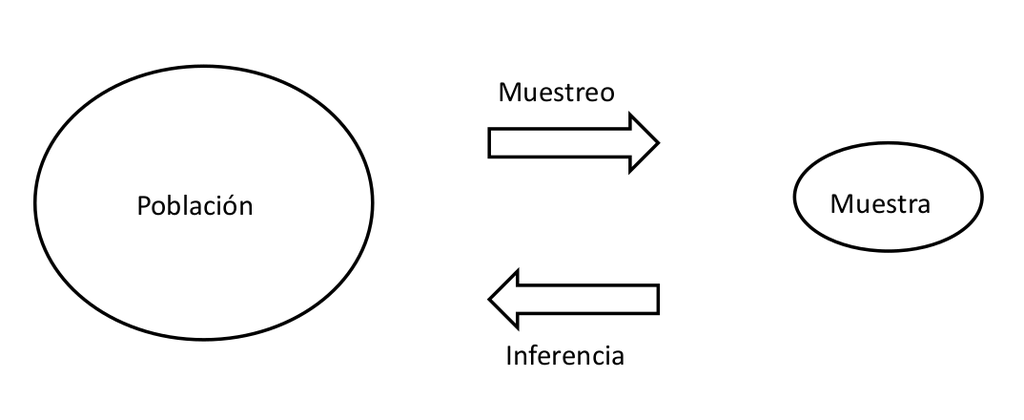

- Métodos de inferencia estadística:
  - Clásico
  - Bayesiano
- Inferencia:
  - Estimación
    - Puntual
    - Intervalos
  - Pruebas de hipótesis

# Estimación de parámetros

## Estimación puntual

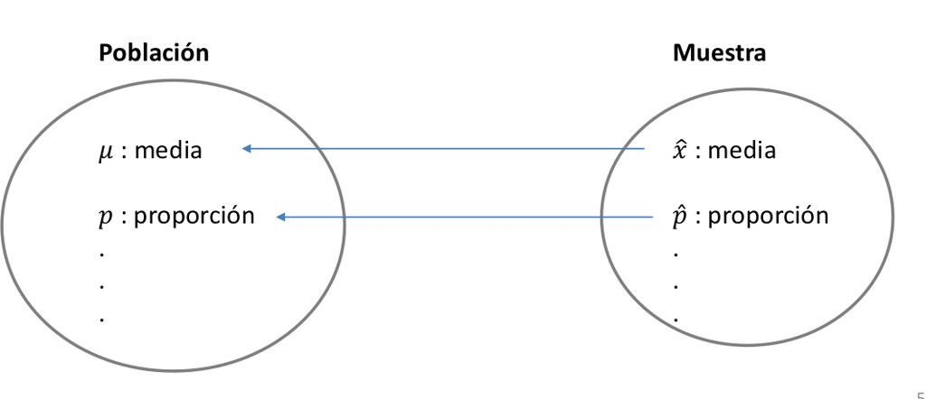

## Estimación por intervalo

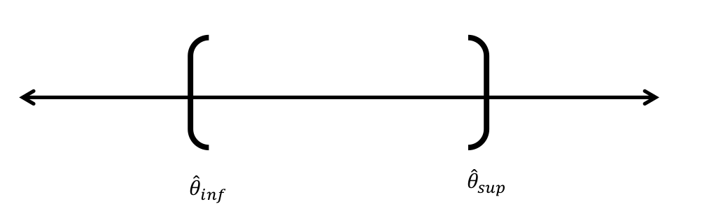

## Nivel $\alpha$ y Nivel de confianza (NC)

- Nivel $\alpha$ de uso frecuente:
  - 0.10
  - 0.05
  - 0.01
- Nivel de confianza de uso frecuente:
  - 0.90
  - 0.95
  - 0.99
- $NC + \alpha = 1$

**Ejemplo con un $NC = 97\%(0.97)$ y $\alpha = 3\%(0.03)$**

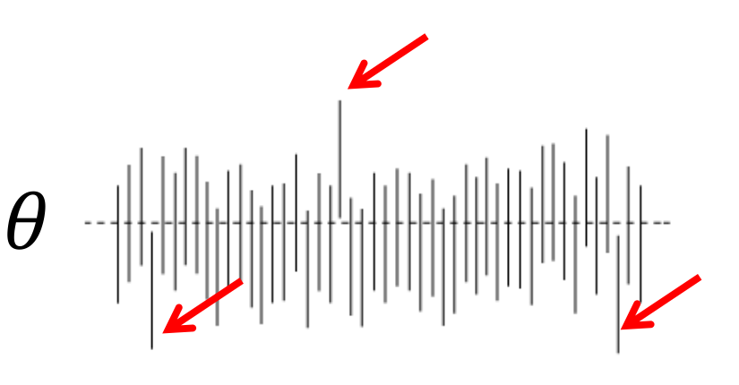

## Intervalos de confianza usuales

- Para una muestra:
  - $\mu$
  - $p$
  - $\sigma^2$
- Para dos muestras:
  - $\mu_1 - \mu_2$
  - $\mu_1 - \mu_2\ (pareadas)$
  - $p_1-p_2$
  - $\sigma^2_1/\sigma^2_2$

# Intervalos de confianza (IC) para una muestra

## IC para $\mu$ con $\sigma$ conocida

Si $\bar{x}$ es la media de una muestra aleatoria de tamaño $n$ de una población normal con varianza $\sigma^2$ conocida, un intervalo de confianza del $(1-\alpha)100\%$ para $\mu$ está dado por la siguiente expresión:

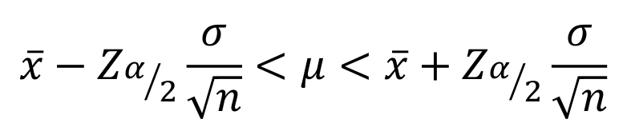

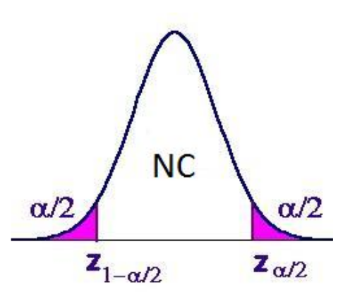

- Nivel de confianza (NC) y $\alpha$: $Z_{\alpha/2}$:
  - $NC = 90\%,\ y\ \alpha = 0.10: Z_{\alpha/2} = 1.645$
  - $NC = 95\%,\ y\ \alpha = 0.05: Z_{\alpha/2} = 1.960$
  - $NC = 99\%,\ y\ \alpha = 0.01: Z_{\alpha/2} = 2.576$

## IC para $\mu$ con $\sigma$ desconocida

Si $\bar{x}$ es la media de una muestra aleatoria de tamaño $n$ de una población normal con varianza $\sigma^2$ desconocida, un intervalo de confianza del $(1-\alpha)100\%$ para $\mu$ está dado por la siguiente expresión:

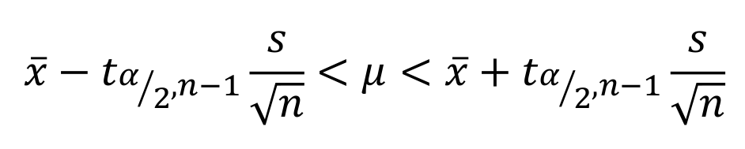

## IC para la varianza $\sigma^2$

Si $\S$ es la varianza de una muestra aleatoria de tamaño $n$ de una población normal, un intervalo de confianza del $(1-\alpha)100\%$ para $\sigma^2$ está dado por la siguiente expresión:

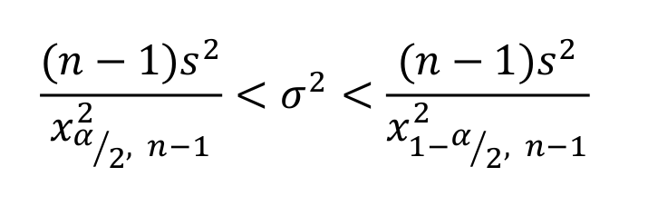

## IC de confianza para la propoción $p$

Si $\hat{p}$ es la proporción de éxitos en una muestra aleatoria de tamaño $n$, un intervalo de confianza del $(1-\alpha)100\%$ para $p$ está dado por la siguiente expresión:

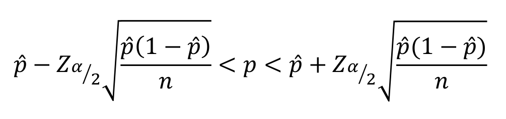

# Intervalos de confianza (IC) para dos muestras

## IC para ($\mu_1-\mu_2$) con $\sigma$ conocida

Si $\bar{X_1}$ y $\bar{X_2}$ son las medias muestrales de dos muestras aleatorias independientes de tamaño $n_1$ y $n_2$ de poblaciones normales con varianzas conocidas $\sigma^2_1$ y $\sigma^2_2$, respectivamente, un intervalo de confianza del $(1-\alpha)100\%$ para $\mu_1-\mu_2$ está dado por la siguiente expresión:

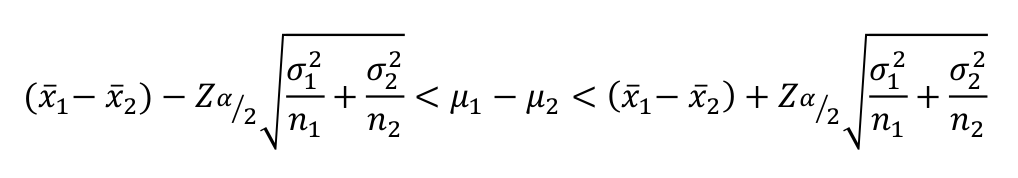

## IC para ($\mu_1-\mu_2$) con $\sigma$ desconocida e iguales

Si $\bar{X_1}$ y $\bar{X_2}$ son las medias muestrales de dos muestras aleatorias independientes de tamaño $n_1$ y $n_2$ de poblaciones normales con varianzas iguales y desconocidas, un intervalo de confianza del $(1-\alpha)100\%$ para $\mu_1-\mu_2$ está dado por la siguiente expresión:

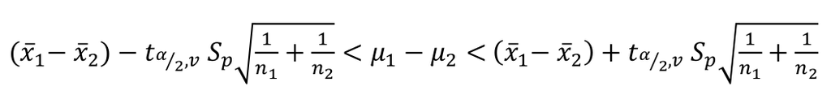

Donde $v = n_1 + n_2 - 2$ y $S^2_p$:

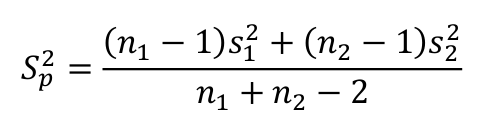

## IC para ($\mu_1-\mu_2$) con $\sigma$ desconocida y diferentes

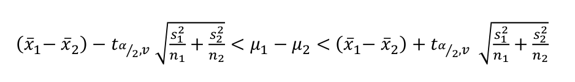

Donde $v$:

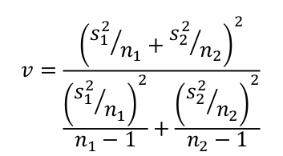

## IC para ($\sigma^2_1/\sigma^2_2$)

Si $S^2_1$ y $S^2_2$ son las varianzas muestrales de muestras aleatorias independientes de tamaño $n_1$ y $n_2$ de poblaciones normales, un intervalo de confianza del $(1-\alpha)100\%$ para $\sigma^2_1/\sigma^2_2$ está dado por la siguiente expresión:

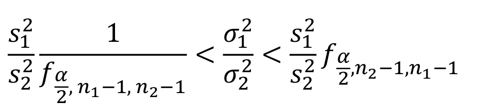

## IC para la $\hat{p_1}-\hat{p_2}$

Si $\hat{p_1}$ y $\hat{p_2}$ son las proporciones de éxito de dos muestras aleatorias independientes de tamaño $n_1$ y $n_2$, entonces un intervalo del $(1-\alpha)100\%$ para $\hat{p_1}-\hat{p_2}$ está dado por la siguiente expresión:

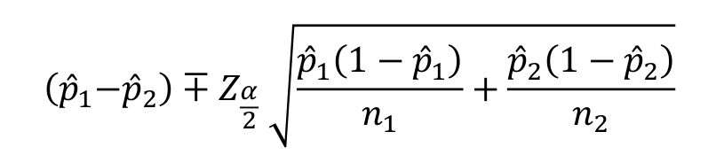